# Cross-Sectional G-Formula

2025-02-11

## The g-formula

- The parametric g-formula allows us to answer key public health questions, such as expected outcomes under various regimes. It allows us to make inference about effects of interventions or treatments
- The g-formula is useful for:
  - target parameters that do not come from a model
  - estimating population-level impacts
  - complex, longitudinal data
  - dynamic exposure and treatment regimes
  - potential outcomes models
- In order to get valid confidence intervals, we must use the bootstrap

## Coal-Fire Power Plant Example

**To estimate the joint effects of air co-pollutants from a coal-fired power plant on 2 year old mental development index (MDI) score under various reduction scenarios**

- Develop a model based on an directed acylic graph (DAG)
- Complete a parametric g-formula analysis using `R` software
- Estimate different joint effects under different reduction scenarios
- Bootstrap confidence intervals for effect estimates under different reduction scenarios
- Interpret results in a causal inference framework

## Install Packages

You will first need to install each packages with `install.packages("packagename")`. Once you have installed once, you may call the package using the `library()` function:

```r
#Load in libraries
library(ggplot2) #for plotting
library(dplyr) #for data cleaning
library(survival) #for survival analysis
library(boot) #for bootstrapping
```

## The Data

Our data set is a (simulated) birth cohort of **3,961** individuals, followed up to 2 years of age in a U.S. city. The outcome of interest is the **Mental Development Index (MDI)** measured at age 2.

The exposures of interest are 3 metals known to be emitted from coal-fired power plants: **arsenic**, **beryllium**, and **cadmium**.

These exposures are measured as annual ambient levels from birth to age 1 via passive monitoring.

The confounder of interest is **urbanicity**.

## The DAG

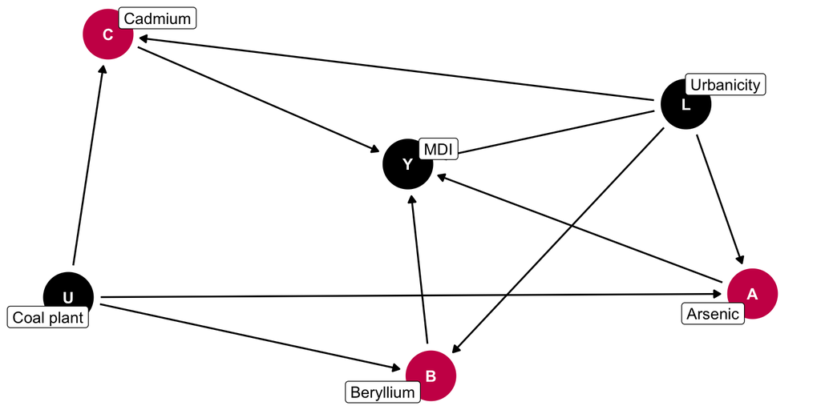

## `coalplant`

```r
coalplant <- read.csv("data/coalplant.csv")
str(coalplant)
```

```
## 'data.frame':    3961 obs. of  6 variables:
##  $ id        : int  1 2 3 4 5 6 7 8 9 10 ...
##  $ as        : num  0.285 0.342 0.877 1.231 0.613 ...
##  $ be        : num  0.31 0.302 1.315 1.731 0.649 ...
##  $ cd        : num  0.313 0.245 1.495 2.218 0.649 ...
##  $ mdi       : num  110 74 140 81 85 104 90 79 69 97 ...
##  $ urbanicity: int  1 1 1 0 1 1 1 1 1 1 ...
```

## Regime 1: Natural Course

The natural course regime assumes no reductions in any of the exposures.

```r
mdimod = lm(mdi ~ as*urbanicity + be*urbanicity + cd*urbanicity +
              as*be + as*cd + be*cd, data=coalplant)
mean(predict(mdimod))
```

```
## [1] 97.31583
```

Under the natural course, where the coal-fire power plant continues to emit arsenic, beryllium, and cadmium, we expect the average MDI of a given child to be 97.316.

## Regime 1: Natural Course

In the natural course case, we expect *no reduction*, or 100%-0%. We are expecting no reduction in any of the exposures. We multiply each of the co-pollutants by the percent reduction expected.

```r
#create new data set for prediction
dat_nc <- coalplant %>%
    mutate(as = as*(1-0.00), #no reduction in as
         be = be*(1-0.00), #no reduction in be
         cd = cd*(1-0.00)) #no reduction in cd

#predict mean MDI
(nc <- mean(predict(mdimod, newdata = dat_nc)))
```

```
## [1] 97.31583
```

Under the natural course, where the coal-fire power plant continues to emit arsenic, beryllium, and cadmium, we expect the average MDI of a given child at age 2 to be 97.316.

## Regime 2: Partial Reductions

```r
#create new data set based on new intervention
dat_no_coal <- coalplant %>%
  mutate(as = as*(1-0.96),
         be = be*(1-0.91),
         cd = cd*(1-0.45))
#predict mean MDI
(no_coal <- mean(predict(mdimod, newdata = dat_no_coal)))
```

```
## [1] 99.92355
```

Under partial reductions, we expect the average MDI of a given child at age 2 to be 99.924.

## Regimes 3: Only Arsenic Set to 0

```r
dat_no_as <- coalplant %>%
  mutate(as = as*0)
#predict mean MDI
(no_as <- mean(predict(mdimod, newdata = dat_no_as)))
```

```
## [1] 97.08229
```

Under arsenic set to 0, we expect the average MDI of a given child at age 2 to be 97.082.

## Regime 4: Only Beryllium Set to 0

```r
dat_no_be <- coalplant %>%
  mutate(be = be*0)
#predict mean MDI
(no_be <- mean(predict(mdimod, newdata = dat_no_be)))
```

```
## [1] 99.15785
```

Under beriyllium set to 0, we expect the average MDI of a given child at age 2 to be 99.158.

## Regime 5: Only Cadmium Set to 0

```r
dat_no_cd <- coalplant %>%
  mutate(cd = cd*0)
#predict mean MDI
(no_cd <- mean(predict(mdimod, newdata = dat_no_cd)))
```

```
## [1] 98.56913
```

Under cadmium set to 0, we expect the average MDI of a given child at age 2 to be 98.569.

## Summary of Regimes 3-5

```r
c(naturalcourse = nc,
  no_coal = no_coal,
  no_arsenic = no_as,
  no_beryllium = no_be,
  no_cadmium = no_cd) %>%
  knitr::kable(col.names = c("Model","Predicted Mean MDI"))
```

| Model | Predicted Mean MDI |
| --- | --- |
| naturalcourse | 97.31583 |
| no_coal | 99.92355 |
| no_arsenic | 97.08229 |
| no_beryllium | 99.15785 |
| no_cadmium | 98.56913 |

## Decomissioning

Under *causal assumptions*, these estimates are equal to counterfactual means under the hypothetical means.

If we wanted to estimate the effect of decommissioning the power plant, we could subtract the mean expected MDI under the natural course from the mean expected MDI under the intervention:

```r
no_coal-nc
```

```
## [1] 2.607721
```

By decommissioning the coal-fire power plant, we can expect and increase of 2.608 MDI of 2 year olds.

## Bootstrapping

When using the g-formula, bootstrapping is often the only way to get valid confidence intervals, though it can be computationally-intensive.

Bootstrapping uses resampling of the data to create an empirical distribution. From that, we can estimate the standard errors of the parameter of interest.

In order to obtain valid confidence intervals, we must bootstrap using the `boot` package. We will create a `function` to loop through the sampled data, estimate the joint effects under the different scenarios `R=500` times. Lastly, the `boot()` function will calculate the *bias* and *standard error* for us. We will then be able to calculate *bootstrapped confidence intervals*.

```r
bootfunc <- function(data, index){
  mcsample = data[index,] #resampled data set
  bootmod = lm(mdi ~ as*urbanicity + be*urbanicity + cd*urbanicity +
                 as*be + as*cd + be*cd, data=mcsample) #model

  #scenarios
  ###natural course
  dat_nc <- mcsample %>%
    mutate(as = as*(1-0.00), #no reduction in as
           be = be*(1-0.00), #no reduction in be
           cd = cd*(1-0.00)) #no reduction in cd
  nc <- mean(predict(bootmod, newdata = dat_nc))

  ###no coal-fire power plant
  dat_no_coal <- mcsample  %>%
  mutate(as = as*(1-0.96),
         be = be*(1-0.91),
         cd = cd*(1-0.45))
  no_coal <- mean(predict(bootmod, newdata = dat_no_coal))

  ###no arsenic
  dat_no_as <- mcsample  %>%
  mutate(as = as*0)
  no_as <- mean(predict(bootmod, newdata = dat_no_as))

  ###no beryllium
  dat_no_be <- mcsample %>%
  mutate(be = be*0)
  no_be <- mean(predict(bootmod, newdata = dat_no_be))

  ###no cadmium
  dat_no_cd <- mcsample  %>%
  mutate(cd = cd*0)
  no_cd <- mean(predict(bootmod, newdata = dat_no_cd))

  #combine estiamtes together to export
  c(nc_mdi=nc, shutdown=no_coal-nc, attrmdi_cd=no_cd-nc, attrmdi_as=no_as-nc, attrmdi_be=no_be-nc)

}
set.seed(2)
bootsamples = boot(data=coalplant, statistic=bootfunc, R=500)
bootsamples
```

```
##
## ORDINARY NONPARAMETRIC BOOTSTRAP
##
##
## Call:
## boot(data = coalplant, statistic = bootfunc, R = 500)
##
##
## Bootstrap Statistics :
##       original       bias    std. error
## t1* 97.3158293 -0.003408230   0.2308952
## t2*  2.6077209  0.135491829   0.8707088
## t3*  1.2532988 -0.019145011   0.4770534
## t4* -0.2335398  0.043268799   0.7519097
## t5*  1.8420160 -0.004491634   0.5888464
```

## Bootstrapping Results

We can look at the first 20 bootstrapped samples for each of the 5 scenarios by accessing the `t` object:

```r
bootsamples$t[1:20,]
```

```
##           [,1]     [,2]      [,3]        [,4]      [,5]
##  [1,] 97.66574 1.749377 1.0924607 -0.03985812 1.3574135
##  [2,] 97.38702 2.860693 1.2537652 -0.98013269 2.1568462
##  [3,] 97.52310 3.003203 1.2019686 -0.52773022 2.4650956
##  [4,] 97.15526 4.580490 0.7917178  0.43885199 2.4795414
##  [5,] 97.86973 2.796064 2.0635324  0.22111691 0.7969950
##  [6,] 97.60919 1.870814 0.9502873  0.10129677 1.5905147
##  [7,] 96.85610 3.310334 1.7113058  0.34905467 1.6996682
##  [8,] 96.93916 2.454644 0.8849235 -0.81974236 1.8002753
##  [9,] 97.62080 3.359343 1.2563761  0.42470447 1.4761066
## [10,] 96.97854 2.182605 1.1992109 -0.85064454 2.6017198
## [11,] 97.21257 3.900217 0.5401451 -0.31040268 2.4964559
## [12,] 97.20853 1.576355 1.8816106 -1.25022482 2.0651108
## [13,] 97.03307 2.300369 2.1177154  0.19205230 1.9079592
## [14,] 97.30725 3.067565 1.3164318  0.05608466 2.3632042
## [15,] 97.05226 3.366381 0.7793274 -0.76153589 2.3723907
## [16,] 97.63570 1.879225 1.0185941  0.19900097 1.6370528
## [17,] 97.12497 2.570180 0.9257450 -0.59776958 1.8073224
## [18,] 97.26332 2.760461 0.7190303 -0.63816341 2.5150579
## [19,] 97.09568 2.091166 1.2999673  0.64562866 0.9232546
## [20,] 97.58167 2.650061 1.6363082  0.61125944 1.1603666
```

To get the standard error we take the standard deviation of the bootstrapped samples using the `sd()` function. We can do this for each of the 5 scenarios by using `apply()` to apply the `sd()` function to each column:

```r
se = apply(bootsamples$t, 2, sd)
se
```

```
## [1] 0.2308952 0.8707088 0.4770534 0.7519097 0.5888464
```

## Final Interpretation

```r
print(cbind(estimate=bootsamples$t0,
            lowerCI=bootsamples$t0-1.96*se,
            upperCI=bootsamples$t0+1.96*se), 3)
```

```
##            estimate lowerCI upperCI
## nc_mdi       97.316  96.863   97.77
## shutdown      2.608   0.901    4.31
## attrmdi_cd    1.253   0.318    2.19
## attrmdi_as   -0.234  -1.707    1.24
## attrmdi_be    1.842   0.688    3.00
```

By shutting down the coal plant, we would expect an increase in mean MDI of 2 year olds to increase by 2.6 points, relative to doing nothing (natural course). This joint effect results in a larger difference in expected MDI score than completely eliminating any one of the co-pollutants on its own.

## Final Thoughts

The parametric g-formula for a point exposure involves a standard regression model, but allows for more flexibility in inference.

## Thank You!

Maria Kamenetsky (maria.kamenetsky@nih.gov)

Alex Keil (alex.keil@nih.gov)